# Trisomy

## Описание датасета

Данные взяты из статьи: 10.1371/journal.pone.0119491. Всего в эксперименте было задействовано 72 мыши: 38 контрольных и 34 с трисомией по хромосоме 21 (синдром Дауна). Мыши разбиваются на 8 классов в зависимости от 3х признаков:

- Генотип - наличие или отсутствие трисомии
- Наличие или остуствие обучения
- Введение мышам лекарства мемантина или физраствора.

Классы наблюдений:

- c-CS-s: контрольные мыши, стимулированные к обучению, введение физраствора (9 мышей)
- c-CS-m: контрольные мыши, стимулированные к обучению, введение мемантина (10 мышей)
- c-SC-s: контрольные мыши, не стимулированные к обучению, введение физраствора (9 мышей)
- c-SC-m: контрольные мыши, не стимулированные к обучению, введение мемантина (10 мышей)
- t-CS-s: мыши с трисомией, стимулированные к обучению, введение физраствора (7 мышей)
- t-CS-m: мыши с трисомией, стимулированные к обучению, введение мемантина (9 мышей)
- t-SC-s: мыши с трисомией, не стимулированные к обучению, введение физраствора (9 мышей)
- t-SC-m: мыши с трисомией, не стимулированные к обучению, введение мемантина (9 мышей)

Число полных наблюдений = 552. Все наблюдения, содержащие NA, мы удаляем.

```r
df <- df %>% na.omit()
df$class <- as.factor(df$class)
```

После предобработки данных, мы наблюдаем следующее распределение семплов по классам:

```r
table(df$class)
```

```
##
## c-CS-m c-CS-s c-SC-m c-SC-s t-CS-m t-CS-s t-SC-m t-SC-s
##     45     75     60     75     90     75     60     72
```

Количество семплов в разных классах мало отклоняется от среднего значения 69, что позволяет говорить о сбалансированности классов.

## Дисперсионный анализ

Необходимо было узнать, есть ли различия в уровне продукции BDNF_N в зависимости от класса в эксперименте. Для начала мы можем посмотреть на средние и доверительные интервалы исходных данных.

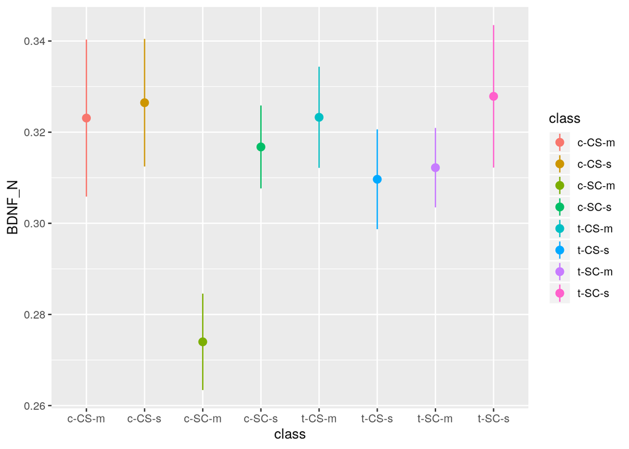

```r
ggplot(df, aes(class, BDNF_N, color = class)) + stat_summary(fun.data = 'mean_cl_normal')
```

На графике мы видим сильное отклонение значений в классе c-SC-m от остальных групп.

Для точной оценки различий уровня продукции BDNF_N мы строим линейную модель зависимости BDNF_N от дискретного предиктора class, с помощью которой проводим дисперсионный анализ в ANOVA.

```r
mod_df <- lm(BDNF_N ~ class, data = df)
df_anova <- anova(mod_df)
df_anova
```

```
## Analysis of Variance Table
##
## Response: BDNF_N
##            Df  Sum Sq   Mean Sq F value   Pr(>F)
## class       7 0.13463 0.0192328   7.304 2.18e-08 ***
## Residuals 544 1.43245 0.0026332
## ---
## Signif. codes:  0 '***' 0.001 '**' 0.01 '*' 0.05 '.' 0.1 ' ' 1
```

Дисперсионный анализ показывает, что уровень экспрессии BDNF_N значимо зависит от генотипа или условий проведения эксперимента (F = 7.304, p_value = 2.18e-08, df1 = 7, df2 = 544). Далее мы проверяем условия применимости нашего анализа.

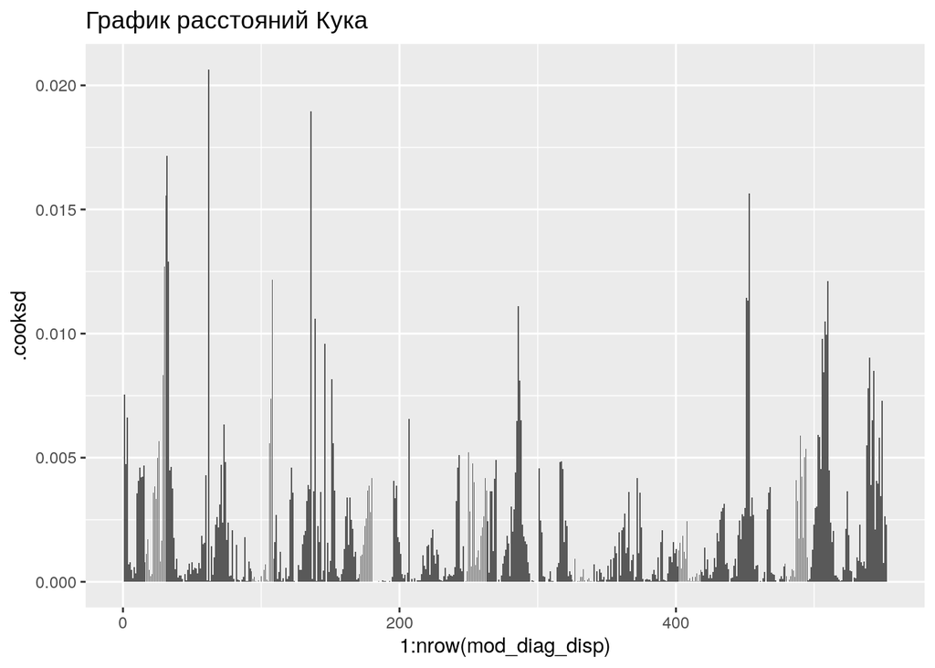

```r
mod_diag_disp <- fortify(mod_df)
ggplot(mod_diag_disp, aes(x = 1:nrow(mod_diag_disp), y = .cooksd)) + geom_bar(stat = 'identity') + ggtitle('График расстояний Кука')
```

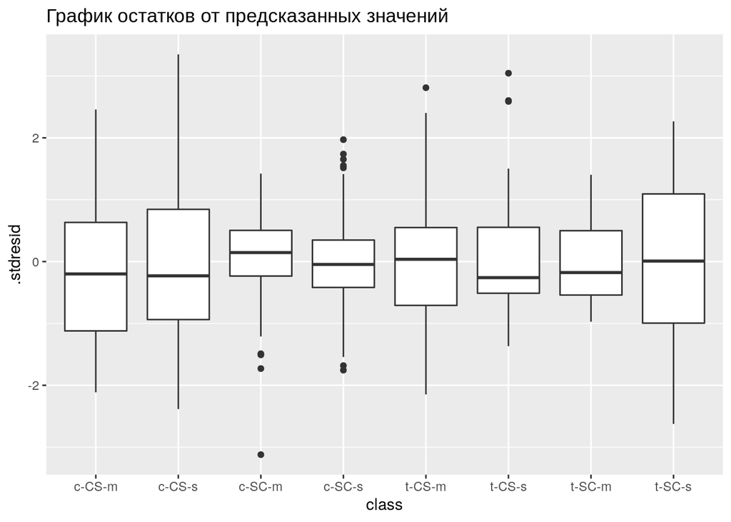

```r
ggplot(mod_diag_disp, aes(x = class, y = .stdresid)) + geom_boxplot() + ggtitle('График остатков от предсказанных значений')
```

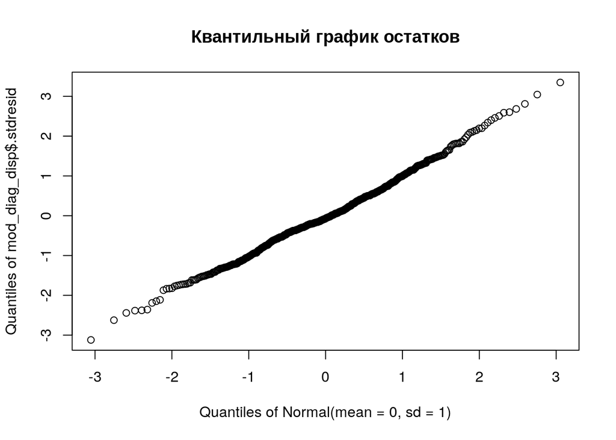

```r
qqPlot(mod_diag_disp$.stdresid, main = 'Квантильный график остатков')
```

График расстояний Кука указывает на отсутствие влиятельных наблюдений. На графике остатков от предсказанных значений видно, что дисперсии в группах распределены равномерно. qqPlot даёт в целом нормальное распределение остатков в модели. Всё это говорит о применимости дисперсионного анализа в данном случае.

Чтобы установить, какие именно классы наблюдений по BDNF_N попарно различаются между собой, необходимо провести пост-хок тесты Хьюки .

```r
post_hoch <- glht(mod_df, linfct = mcp(class = 'Tukey'))
summary(post_hoch)
```

```
##
##   Simultaneous Tests for General Linear Hypotheses
##
## Multiple Comparisons of Means: Tukey Contrasts
##
##
## Fit: lm(formula = BDNF_N ~ class, data = df)
##
## Linear Hypotheses:
##                        Estimate Std. Error t value Pr(>|t|)
## c-CS-s - c-CS-m == 0  0.0033693  0.0096760   0.348  0.99997
## c-SC-m - c-CS-m == 0 -0.0491100  0.0101194  -4.853  < 0.001 ***
## c-SC-s - c-CS-m == 0 -0.0063413  0.0096760  -0.655  0.99799
## t-CS-m - c-CS-m == 0  0.0001672  0.0093687   0.018  1.00000
## t-CS-s - c-CS-m == 0 -0.0134348  0.0096760  -1.388  0.86129
## t-SC-m - c-CS-m == 0 -0.0108874  0.0101194  -1.076  0.96122
## t-SC-s - c-CS-m == 0  0.0047657  0.0097513   0.489  0.99970
## c-SC-m - c-CS-s == 0 -0.0524793  0.0088879  -5.905  < 0.001 ***
## c-SC-s - c-CS-s == 0 -0.0097107  0.0083796  -1.159  0.94239
## t-CS-m - c-CS-s == 0 -0.0032021  0.0080229  -0.399  0.99992
## t-CS-s - c-CS-s == 0 -0.0168041  0.0083796  -2.005  0.47693
## t-SC-m - c-CS-s == 0 -0.0142568  0.0088879  -1.604  0.74603
## t-SC-s - c-CS-s == 0  0.0013964  0.0084665   0.165  1.00000
## c-SC-s - c-SC-m == 0  0.0427687  0.0088879   4.812  < 0.001 ***
## t-CS-m - c-SC-m == 0  0.0492772  0.0085524   5.762  < 0.001 ***
## t-CS-s - c-SC-m == 0  0.0356752  0.0088879   4.014  0.00161 **
## t-SC-m - c-SC-m == 0  0.0382226  0.0093687   4.080  0.00128 **
## t-SC-s - c-SC-m == 0  0.0538757  0.0089698   6.006  < 0.001 ***
## t-CS-m - c-SC-s == 0  0.0065085  0.0080229   0.811  0.99239
## t-CS-s - c-SC-s == 0 -0.0070935  0.0083796  -0.847  0.99016
## t-SC-m - c-SC-s == 0 -0.0045461  0.0088879  -0.511  0.99960
## t-SC-s - c-SC-s == 0  0.0111070  0.0084665   1.312  0.89343
## t-CS-s - t-CS-m == 0 -0.0136020  0.0080229  -1.695  0.68854
## t-SC-m - t-CS-m == 0 -0.0110546  0.0085524  -1.293  0.90062
## t-SC-s - t-CS-m == 0  0.0045985  0.0081135   0.567  0.99921
## t-SC-m - t-CS-s == 0  0.0025473  0.0088879   0.287  0.99999
## t-SC-s - t-CS-s == 0  0.0182005  0.0084665   2.150  0.38229
## t-SC-s - t-SC-m == 0  0.0156531  0.0089698   1.745  0.65554
## ---
## Signif. codes:  0 '***' 0.001 '**' 0.01 '*' 0.05 '.' 0.1 ' ' 1
## (Adjusted p values reported -- single-step method)
```

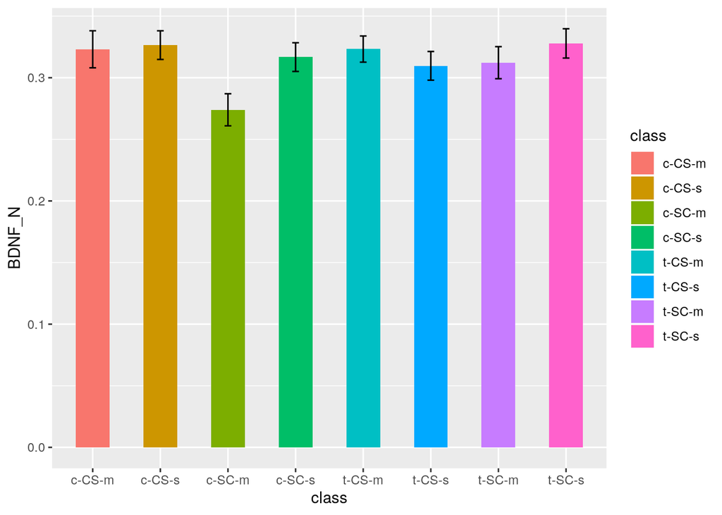

```r
MyData <- data.frame(class = factor(levels(df$class), levels = levels(df$class)))
MyData <- data.frame(MyData, predict(mod_df, newdata = MyData, interval = 'confidence'))

gg_bars <- ggplot(data = MyData, aes(x = class, y = fit)) + geom_bar(stat = 'identity', aes(fill = class), width = 0.5) + geom_errorbar(aes(ymin = lwr, ymax = upr), width = 0.1)
gg_bars + ylab(label = 'BDNF_N')
```

## Построение модели

Следующим шагом была попытка построить многомерную линейную модель, способную предсказать уровень продукции белка ERBB4_N на основании данных о других белках в эксперименте. Самой большой проблемой при построении модели с таким большим количеством предикторов является мультиколлинеарность. Чаще всего в этом случае используют метод главных компонент (PCA), с помощью которого можно объединять все коррелирующие предикторы в главные компоненты. Сейчас мы попробуем построить линейную модель традиционным методом отбора предикторов по коллинеарности и значимости. Сперва построим полную модель.

```r
model_data <- df[, 2:78]
mod_1 <- lm(ERBB4_N ~ ., model_data)
summary(mod_1)
```

```
##
## Call:
## lm(formula = ERBB4_N ~ ., data = model_data)
##
## Residuals:
##       Min        1Q    Median        3Q       Max
## -0.023037 -0.003370 -0.000127  0.003071  0.031955
##
## Coefficients: (1 not defined because of singularities)
##                   Estimate Std. Error t value Pr(>|t|)
## (Intercept)      2.566e-02  8.245e-03   3.112 0.001970 **
## DYRK1A_N        -6.824e-03  7.475e-03  -0.913 0.361710
## ITSN1_N          8.127e-03  1.058e-02   0.768 0.442776
## BDNF_N           3.833e-02  1.919e-02   1.997 0.046378 *
## NR1_N           -1.409e-02  6.685e-03  -2.108 0.035544 *
## NR2A_N          -1.049e-04  1.361e-03  -0.077 0.938610
## pAKT_N           7.961e-02  3.044e-02   2.615 0.009203 **
## pBRAF_N         -4.103e-02  3.065e-02  -1.339 0.181356
## pCAMKII_N       -1.451e-05  7.954e-04  -0.018 0.985451
## pCREB_N         -6.015e-02  2.910e-02  -2.067 0.039290 *
## pELK_N           4.731e-05  1.030e-03   0.046 0.963391
## pERK_N          -1.987e-02  7.887e-03  -2.519 0.012109 *
## pJNK_N          -6.035e-02  2.538e-02  -2.378 0.017814 *
## PKCA_N           8.377e-03  2.736e-02   0.306 0.759625
## pMEK_N           8.498e-03  2.706e-02   0.314 0.753676
## pNR1_N          -2.566e-02  1.334e-02  -1.924 0.054968 .
## pNR2A_N          1.004e-02  7.239e-03   1.388 0.165927
## pNR2B_N          1.928e-02  6.659e-03   2.896 0.003959 **
## pPKCAB_N         5.727e-03  2.773e-03   2.065 0.039457 *
## pRSK_N           1.001e-02  1.427e-02   0.701 0.483573
## AKT_N           -6.738e-04  8.183e-03  -0.082 0.934413
## BRAF_N           1.550e-02  1.213e-02   1.278 0.201926
## CAMKII_N        -3.429e-03  2.011e-02  -0.170 0.864700
## CREB_N          -1.450e-02  3.091e-02  -0.469 0.639135
## ELK_N            3.510e-03  3.719e-03   0.944 0.345811
## ERK_N            4.660e-03  2.804e-03   1.662 0.097208 .
## GSK3B_N         -5.840e-03  6.824e-03  -0.856 0.392588
## JNK_N           -1.188e-02  3.378e-02  -0.352 0.725317
## MEK_N            8.785e-03  2.197e-02   0.400 0.689510
## TRKA_N           5.722e-03  1.646e-02   0.348 0.728257
```

[output cut: 38 more lines]

```
## BAD_N           -3.592e-02  3.508e-02  -1.024 0.306311
## BCL2_N           6.173e-03  3.112e-02   0.198 0.842840
## pS6_N                   NA         NA      NA       NA
## pCFOS_N         -1.232e-02  3.111e-02  -0.396 0.692240
## SYP_N            1.354e-02  1.079e-02   1.254 0.210395
## H3AcK18_N        2.401e-03  2.527e-02   0.095 0.924349
## EGR1_N          -6.016e-03  2.619e-02  -0.230 0.818406
## H3MeK4_N         1.227e-02  2.154e-02   0.570 0.569097
## CaNA_N          -1.749e-03  3.419e-03  -0.512 0.609159
## ---
## Signif. codes:  0 '***' 0.001 '**' 0.01 '*' 0.05 '.' 0.1 ' ' 1
##
## Residual standard error: 0.005885 on 476 degrees of freedom
## Multiple R-squared:  0.8641, Adjusted R-squared:  0.8427
## F-statistic: 40.37 on 75 and 476 DF,  p-value: < 2.2e-16
```

Так как все параметры измерялись в одинаковых единицах размерности, мы не будем проводить стандартизацию и сразу перейдем к отбору предикторов по мультиколлинеарности.

```r
#alias(mod_1)
mod_2 <- update(mod_1, .~. - ARC_N)

vif(mod_2)
```

```
##        DYRK1A_N         ITSN1_N          BDNF_N           NR1_N
##       23.736607       59.473637       16.669610       96.311682
##          NR2A_N          pAKT_N         pBRAF_N       pCAMKII_N
##       25.127918       21.880134        9.671403       19.251803
##         pCREB_N          pELK_N          pERK_N          pJNK_N
##       17.421324        2.584965       55.739024       26.508561
##          PKCA_N          pMEK_N          pNR1_N         pNR2A_N
##       38.653895       23.634116       44.380168       33.053974
##         pNR2B_N        pPKCAB_N          pRSK_N           AKT_N
##       55.826515       33.036076       15.913962       17.993694
##          BRAF_N        CAMKII_N          CREB_N           ELK_N
##       41.690503       16.062122        9.992444       29.844699
##           ERK_N         GSK3B_N           JNK_N           MEK_N
##       55.249434       32.819856       18.997732       15.629309
##          TRKA_N           RSK_N           APP_N      Bcatenin_N
##       72.480935       16.236937       21.563500       91.994091
##          SOD1_N          MTOR_N           P38_N         pMTOR_N
##       20.108411       17.860768       19.953844       17.905757
##         DSCR1_N         AMPKA_N          NR2B_N         pNUMB_N
##       14.567686       27.108067       11.017845       20.067495
##        RAPTOR_N         TIAM1_N        pP70S6_N          NUMB_N
##       19.127590       21.793679        9.784679       23.482651
##         P70S6_N        pGSK3B_N         pPKCG_N          CDK5_N
##       13.516220       12.102837       22.052092        2.976573
##            S6_N        ADARB1_N    AcetylH3K9_N          RRP1_N
##       17.503666        9.335931       42.778299        1.716449
##           BAX_N          nNOS_N           Tau_N          GFAP_N
##        8.071101        9.589675       17.829428        5.422842
##         GluR3_N         GluR4_N          IL1B_N         P3525_N
##       10.719066        8.004983        9.575112        7.896508
##        pCASP9_N         PSD95_N          SNCA_N     Ubiquitin_N
##        9.082792       14.501625        9.291047       10.532632
## pGSK3B_Tyr216_N           SHH_N           BAD_N          BCL2_N
##       11.355079        5.101022       13.413137        8.480518
##           pS6_N         pCFOS_N           SYP_N       H3AcK18_N
##       14.624584        6.364879        9.429731       36.335690
##          EGR1_N        H3MeK4_N          CaNA_N
##       13.981307       15.299243       19.739341
```

```r
names(vif(mod_2))[which.max(vif(mod_2))]
```

```
## [1] "NR1_N"
```

```r
mod_3 <- update(mod_2, .~. - NR1_N)

#vif(mod_3)
names(vif(mod_3))[which.max(vif(mod_3))]
```

```
## [1] "Bcatenin_N"
```

```r
mod_4 <- update(mod_3, .~. - Bcatenin_N)

#vif(mod_4)
names(vif(mod_4))[which.max(vif(mod_4))]
```

```
## [1] "TRKA_N"
```

```r
mod_5 <- update(mod_4, .~. - TRKA_N)

#vif(mod_5)
names(vif(mod_5))[which.max(vif(mod_5))]
```

```
## [1] "ITSN1_N"
```

```r
mod_6 <- update(mod_5, .~. - ITSN1_N)

#vif(mod_6)
names(vif(mod_6))[which.max(vif(mod_6))]
```

```
## [1] "pERK_N"
```

```r
mod_7 <- update(mod_6, .~. - pERK_N)

#vif(mod_7)
names(vif(mod_7))[which.max(vif(mod_7))]
```

```
## [1] "pNR2B_N"
```

```r
mod_8 <- update(mod_7, .~. - pNR2B_N)

#vif(mod_8)
names(vif(mod_8))[which.max(vif(mod_8))]
```

```
## [1] "AcetylH3K9_N"
```

```r
mod_9 <- update(mod_8, .~. - AcetylH3K9_N)

#vif(mod_9)
names(vif(mod_9))[which.max(vif(mod_9))]
```

```
## [1] "ERK_N"
```

```r
mod_10 <- update(mod_9, .~. - ERK_N)

#vif(mod_10)
names(vif(mod_10))[which.max(vif(mod_10))]
```

```
## [1] "PKCA_N"
```

```r
mod_11 <- update(mod_10, .~. - PKCA_N)

#vif(mod_11)
names(vif(mod_11))[which.max(vif(mod_11))]
```

```
## [1] "ELK_N"
```

```r
mod_12 <- update(mod_11, .~. - ELK_N)

#vif(mod_12)
names(vif(mod_12))[which.max(vif(mod_12))]
```

```
## [1] "pNR1_N"
```

```r
mod_13 <- update(mod_12, .~. - pNR1_N)

#vif(mod_13)
names(vif(mod_13))[which.max(vif(mod_13))]
```

```
## [1] "GSK3B_N"
```

```r
mod_14 <- update(mod_13, .~. - GSK3B_N)

#vif(mod_14)
names(vif(mod_14))[which.max(vif(mod_14))]
```

```
## [1] "AMPKA_N"
```

```r
mod_15 <- update(mod_14, .~. - AMPKA_N)

#vif(mod_15)
names(vif(mod_15))[which.max(vif(mod_15))]
```

```
## [1] "pJNK_N"
```

```r
mod_16 <- update(mod_15, .~. - pJNK_N)

#vif(mod_16)
names(vif(mod_16))[which.max(vif(mod_16))]
```

```
## [1] "NUMB_N"
```

```r
mod_17 <- update(mod_16, .~. - NUMB_N)

#vif(mod_17)
names(vif(mod_17))[which.max(vif(mod_17))]
```

```
## [1] "pPKCAB_N"
```

```r
mod_18 <- update(mod_17, .~. - pPKCAB_N)

#vif(mod_18)
names(vif(mod_18))[which.max(vif(mod_18))]
```

```
## [1] "DYRK1A_N"
```

```r
mod_19 <- update(mod_18, .~. - DYRK1A_N)

#vif(mod_19)
names(vif(mod_19))[which.max(vif(mod_19))]
```

```
## [1] "pAKT_N"
```

```r
mod_20 <- update(mod_19, .~. - pAKT_N)

#vif(mod_20)
names(vif(mod_20))[which.max(vif(mod_20))]
```

```
## [1] "JNK_N"
```

```r
mod_21 <- update(mod_20, .~. - JNK_N)

#vif(mod_21)
names(vif(mod_21))[which.max(vif(mod_21))]
```

```
## [1] "RAPTOR_N"
```

```r
mod_22 <- update(mod_21, .~. - RAPTOR_N)

#vif(mod_22)
names(vif(mod_22))[which.max(vif(mod_22))]
```

```
## [1] "MTOR_N"
```

```r
mod_23 <- update(mod_22, .~. - MTOR_N)

#vif(mod_23)
names(vif(mod_23))[which.max(vif(mod_23))]
```

```
## [1] "CaNA_N"
```

```r
mod_24 <- update(mod_23, .~. - CaNA_N)

#vif(mod24)
names(vif(mod_24))[which.max(vif(mod_24))]
```

```
## [1] "NR2A_N"
```

```r
mod_25 <- update(mod_24, .~. - NR2A_N)

#vif(mod_25)
names(vif(mod_25))[which.max(vif(mod_25))]
```

```
## [1] "pMEK_N"
```

```r
mod_26 <- update(mod_25, .~. - pMEK_N)

#vif(mod_26)
names(vif(mod_26))[which.max(vif(mod_26))]
```

```
## [1] "H3MeK4_N"
```

```r
mod_27 <- update(mod_26, .~. - H3MeK4_N)

#vif(mod_27)
names(vif(mod_27))[which.max(vif(mod_27))]
```

```
## [1] "pPKCG_N"
```

```r
mod_28 <- update(mod_27, .~. - pPKCG_N)

#vif(mod_28)
names(vif(mod_28))[which.max(vif(mod_28))]
```

```
## [1] "BDNF_N"
```

```r
mod_29 <- update(mod_28, .~. - BDNF_N)

#vif(mod_29)
names(vif(mod_29))[which.max(vif(mod_29))]
```

```
## [1] "TIAM1_N"
```

```r
mod_30 <- update(mod_29, .~. - TIAM1_N)

#vif(mod_30)
names(vif(mod_30))[which.max(vif(mod_30))]
```

```
## [1] "pMTOR_N"
```

```r
mod_31 <- update(mod_30, .~. - pMTOR_N)

#vif(mod_31)
names(vif(mod_31))[which.max(vif(mod_31))]
```

```
## [1] "pS6_N"
```

```r
mod_32 <- update(mod_31, .~. - pS6_N)

#vif(mod_32)
names(vif(mod_32))[which.max(vif(mod_32))]
```

```
## [1] "MEK_N"
```

```r
mod_33 <- update(mod_32, .~. - MEK_N)

#vif(mod_33)
names(vif(mod_33))[which.max(vif(mod_33))]
```

```
## [1] "EGR1_N"
```

```r
mod_34 <- update(mod_33, .~. - EGR1_N)

#vif(mod_34)
names(vif(mod_34))[which.max(vif(mod_34))]
```

```
## [1] "CAMKII_N"
```

```r
mod_35 <- update(mod_34, .~. - CAMKII_N)

#vif(mod_35)
names(vif(mod_35))[which.max(vif(mod_35))]
```

```
## [1] "pCREB_N"
```

```r
mod_36 <- update(mod_35, .~. - pCREB_N)

#vif(mod_36)
names(vif(mod_36))[which.max(vif(mod_36))]
```

```
## [1] "pNR2A_N"
```

```r
mod_37 <- update(mod_36, .~. - pNR2A_N)

#vif(mod_37)
names(vif(mod_37))[which.max(vif(mod_37))]
```

```
## [1] "NR2B_N"
```

```r
mod_38 <- update(mod_37, .~. - NR2B_N)

#vif(mod_38)
names(vif(mod_38))[which.max(vif(mod_38))]
```

```
## [1] "CREB_N"
```

```r
mod_39 <- update(mod_38, .~. - CREB_N)

#vif(mod_39)
names(vif(mod_39))[which.max(vif(mod_39))]
```

```
## [1] "Ubiquitin_N"
```

```r
mod_40 <- update(mod_39, .~. - Ubiquitin_N)

#vif(mod_40)
names(vif(mod_40))[which.max(vif(mod_40))]
```

```
## [1] "pRSK_N"
```

```r
mod_41 <- update(mod_40, .~. - pRSK_N)

#vif(mod_40)
names(vif(mod_40))[which.max(vif(mod_40))]
```

```
## [1] "pRSK_N"
```

```r
mod_41 <- update(mod_40, .~. - pRSK_N)

#vif(mod_41)
names(vif(mod_41))[which.max(vif(mod_41))]
```

```
## [1] "BAD_N"
```

```r
mod_42 <- update(mod_41, .~. - BAD_N)

#vif(mod_42)
names(vif(mod_42))[which.max(vif(mod_42))]
```

```
## [1] "Tau_N"
```

```r
mod_43 <- update(mod_42, .~. - Tau_N)

#vif(mod_43)
names(vif(mod_43))[which.max(vif(mod_43))]
```

```
## [1] "pNUMB_N"
```

```r
mod_44 <- update(mod_43, .~. - pNUMB_N)

#vif(mod_44)
names(vif(mod_44))[which.max(vif(mod_44))]
```

```
## [1] "S6_N"
```

```r
mod_45 <- update(mod_44, .~. - S6_N)

#vif(mod_45)
names(vif(mod_45))[which.max(vif(mod_45))]
```

```
## [1] "pBRAF_N"
```

```r
mod_46 <- update(mod_45, .~. - pBRAF_N)

#vif(mod_46)
names(vif(mod_46))[which.max(vif(mod_46))]
```

```
## [1] "pGSK3B_N"
```

```r
mod_47 <- update(mod_46, .~. - pGSK3B_N)

#vif(mod_47)
names(vif(mod_47))[which.max(vif(mod_47))]
```

```
## [1] "GluR3_N"
```

```r
mod_48 <- update(mod_47, .~. - GluR3_N)

#vif(mod_48)
names(vif(mod_48))[which.max(vif(mod_48))]
```

```
## [1] "P70S6_N"
```

```r
mod_49 <- update(mod_48, .~. - P70S6_N)

#vif(mod_49)
names(vif(mod_49))[which.max(vif(mod_49))]
```

```
## [1] "P38_N"
```

```r
mod_50 <- update(mod_49, .~. - P38_N)

#vif(mod_50)
names(vif(mod_50))[which.max(vif(mod_50))]
```

```
## [1] "nNOS_N"
```

```r
mod_51 <- update(mod_50, .~. - nNOS_N)

#vif(mod_51)
names(vif(mod_51))[which.max(vif(mod_51))]
```

```
## [1] "IL1B_N"
```

```r
mod_52 <- update(mod_51, .~. - IL1B_N)

#vif(mod_52)
names(vif(mod_52))[which.max(vif(mod_52))]
```

```
## [1] "AKT_N"
```

```r
mod_53 <- update(mod_52, .~. - AKT_N)

#vif(mod_53)
a <- names(vif(mod_53))[which.max(vif(mod_53))]
mod_54 <- update(mod_53, .~. - BCL2_N)

names(vif(mod_54))[which.max(vif(mod_54))]
```

```
## [1] "BRAF_N"
```

```r
mod_55 <- update(mod_54, .~. - BRAF_N)

names(vif(mod_55))[which.max(vif(mod_55))]
```

```
## [1] "PSD95_N"
```

```r
mod_56 <- update(mod_55, .~. - PSD95_N)

#vif(mod_56)
names(vif(mod_56))[which.max(vif(mod_56))]
```

```
## [1] "P3525_N"
```

```r
mod_57 <- update(mod_56, .~. - P3525_N)

#vif(mod_57)
names(vif(mod_57))[which.max(vif(mod_57))]
```

```
## [1] "SYP_N"
```

```r
mod_58 <- update(mod_57, .~. - SYP_N)

#vif(mod_58)
names(vif(mod_58))[which.max(vif(mod_58))]
```

```
## [1] "pCFOS_N"
```

```r
mod_59 <- update(mod_58, .~. - pCFOS_N)

#vif(mod_59)
names(vif(mod_59))[which.max(vif(mod_59))]
```

```
## [1] "BAX_N"
```

```r
mod_60 <- update(mod_59, .~. - BAX_N)

#vif(mod_60)
names(vif(mod_60))[which.max(vif(mod_60))]
```

```
## [1] "GluR4_N"
```

```r
mod_61 <- update(mod_60, .~. - GluR4_N)

#vif(mod_61)
names(vif(mod_61))[which.max(vif(mod_61))]
```

```
## [1] "APP_N"
```

```r
mod_62 <- update(mod_61, .~. - APP_N)

vif(mod_62)
```

```
##       pCAMKII_N          pELK_N           RSK_N          SOD1_N
##        1.895865        1.354909        1.804962        1.951276
##         DSCR1_N        pP70S6_N          CDK5_N        ADARB1_N
##        1.800211        1.879518        1.792827        1.488468
##          RRP1_N          GFAP_N        pCASP9_N          SNCA_N
##        1.290845        1.820934        1.799952        1.996059
## pGSK3B_Tyr216_N           SHH_N       H3AcK18_N
##        2.063241        1.784254        1.646770
```

```r
names(vif(mod_62))[which.max(vif(mod_62))]
```

```
## [1] "pGSK3B_Tyr216_N"
```

```r
mod_63 <- update(mod_62, .~. - pGSK3B_Tyr216_N)

vif(mod_63)
```

```
## pCAMKII_N    pELK_N     RSK_N    SOD1_N   DSCR1_N  pP70S6_N    CDK5_N
##  1.895677  1.354908  1.762407  1.755229  1.759048  1.797288  1.675283
##  ADARB1_N    RRP1_N    GFAP_N  pCASP9_N    SNCA_N     SHH_N H3AcK18_N
##  1.447068  1.290564  1.820407  1.549181  1.918910  1.452835  1.646402
```

```r
drop1(mod_63, test = 'F')
```

```
## Single term deletions
##
## Model:
## ERBB4_N ~ pCAMKII_N + pELK_N + RSK_N + SOD1_N + DSCR1_N + pP70S6_N +
##     CDK5_N + ADARB1_N + RRP1_N + GFAP_N + pCASP9_N + SNCA_N +
##     SHH_N + H3AcK18_N
##           Df Sum of Sq      RSS     AIC  F value    Pr(>F)
## <none>                 0.040374 -5226.8
## pCAMKII_N  1 0.0003663 0.040740 -5223.8   4.8721 0.0277163 *
## pELK_N     1 0.0001072 0.040481 -5227.3   1.4262 0.2329120
## RSK_N      1 0.0022763 0.042650 -5198.5  30.2758  5.81e-08 ***
## SOD1_N     1 0.0004406 0.040814 -5222.8   5.8599 0.0158205 *
## DSCR1_N    1 0.0002896 0.040663 -5224.8   3.8524 0.0501921 .
## pP70S6_N   1 0.0002950 0.040669 -5224.7   3.9231 0.0481365 *
## CDK5_N     1 0.0003760 0.040750 -5223.6   5.0006 0.0257491 *
## ADARB1_N   1 0.0073204 0.047694 -5136.8  97.3660 < 2.2e-16 ***
## RRP1_N     1 0.0000491 0.040423 -5228.1   0.6535 0.4192240
## GFAP_N     1 0.0009733 0.041347 -5215.6  12.9459 0.0003503 ***
## pCASP9_N   1 0.0149914 0.055365 -5054.5 199.3955 < 2.2e-16 ***
## SNCA_N     1 0.0008157 0.041190 -5217.7  10.8488 0.0010537 **
## SHH_N      1 0.0054830 0.045857 -5158.5  72.9270 < 2.2e-16 ***
## H3AcK18_N  1 0.0058749 0.046249 -5153.8  78.1405 < 2.2e-16 ***
## ---
## Signif. codes:  0 '***' 0.001 '**' 0.01 '*' 0.05 '.' 0.1 ' ' 1
```

```r
mod_64 <- update(mod_63, .~. - RRP1_N)

drop1(mod_64, test = 'F')
```

```
## Single term deletions
##
## Model:
## ERBB4_N ~ pCAMKII_N + pELK_N + RSK_N + SOD1_N + DSCR1_N + pP70S6_N +
##     CDK5_N + ADARB1_N + GFAP_N + pCASP9_N + SNCA_N + SHH_N +
##     H3AcK18_N
##           Df Sum of Sq      RSS     AIC  F value    Pr(>F)
## <none>                 0.040423 -5228.1
## pCAMKII_N  1 0.0003543 0.040777 -5225.3   4.7161  0.030318 *
## pELK_N     1 0.0001079 0.040531 -5228.6   1.4360  0.231312
## RSK_N      1 0.0022435 0.042667 -5200.3  29.8596 7.114e-08 ***
## SOD1_N     1 0.0004384 0.040861 -5224.1   5.8347  0.016045 *
## DSCR1_N    1 0.0002872 0.040710 -5226.2   3.8226  0.051082 .
## pP70S6_N   1 0.0002837 0.040707 -5226.2   3.7764  0.052503 .
## CDK5_N     1 0.0003614 0.040784 -5225.2   4.8106  0.028713 *
## ADARB1_N   1 0.0075778 0.048001 -5135.2 100.8550 < 2.2e-16 ***
## GFAP_N     1 0.0012354 0.041658 -5213.5  16.4417 5.758e-05 ***
## pCASP9_N   1 0.0149977 0.055421 -5055.9 199.6088 < 2.2e-16 ***
## SNCA_N     1 0.0008024 0.041225 -5219.2  10.6788  0.001153 **
## SHH_N      1 0.0054887 0.045912 -5159.8  73.0503 < 2.2e-16 ***
## H3AcK18_N  1 0.0058288 0.046252 -5155.7  77.5765 < 2.2e-16 ***
## ---
## Signif. codes:  0 '***' 0.001 '**' 0.01 '*' 0.05 '.' 0.1 ' ' 1
```

```r
mod_65 <- update(mod_64, .~. - pELK_N)

drop1(mod_65, test = 'F')
```

```
## Single term deletions
##
## Model:
## ERBB4_N ~ pCAMKII_N + RSK_N + SOD1_N + DSCR1_N + pP70S6_N + CDK5_N +
##     ADARB1_N + GFAP_N + pCASP9_N + SNCA_N + SHH_N + H3AcK18_N
##           Df Sum of Sq      RSS     AIC  F value    Pr(>F)
## <none>                 0.040531 -5228.6
## pCAMKII_N  1 0.0003626 0.040893 -5225.7   4.8221  0.028523 *
## RSK_N      1 0.0024991 0.043030 -5197.6  33.2341 1.377e-08 ***
## SOD1_N     1 0.0004714 0.041002 -5224.2   6.2692  0.012580 *
## DSCR1_N    1 0.0002240 0.040755 -5227.6   2.9784  0.084958 .
## pP70S6_N   1 0.0003428 0.040874 -5226.0   4.5582  0.033211 *
## CDK5_N     1 0.0003236 0.040854 -5226.2   4.3031  0.038517 *
## ADARB1_N   1 0.0078074 0.048338 -5133.4 103.8270 < 2.2e-16 ***
## GFAP_N     1 0.0011757 0.041707 -5214.8  15.6345 8.709e-05 ***
## pCASP9_N   1 0.0148937 0.055425 -5057.9 198.0632 < 2.2e-16 ***
## SNCA_N     1 0.0007104 0.041241 -5221.0   9.4477  0.002221 **
## SHH_N      1 0.0054460 0.045977 -5161.0  72.4238 < 2.2e-16 ***
## H3AcK18_N  1 0.0057264 0.046257 -5157.7  76.1525 < 2.2e-16 ***
## ---
## Signif. codes:  0 '***' 0.001 '**' 0.01 '*' 0.05 '.' 0.1 ' ' 1
```

```r
mod_66 <- update(mod_65, .~. - DSCR1_N)

drop1(mod_66, test = 'F')
```

```
## Single term deletions
##
## Model:
## ERBB4_N ~ pCAMKII_N + RSK_N + SOD1_N + pP70S6_N + CDK5_N + ADARB1_N +
##     GFAP_N + pCASP9_N + SNCA_N + SHH_N + H3AcK18_N
##           Df Sum of Sq      RSS     AIC  F value    Pr(>F)
## <none>                 0.040755 -5227.6
## pCAMKII_N  1 0.0002802 0.041035 -5225.8   3.7122 0.0545399 .
## RSK_N      1 0.0023415 0.043096 -5198.7  31.0242 4.024e-08 ***
## SOD1_N     1 0.0004817 0.041237 -5223.1   6.3827 0.0118085 *
## pP70S6_N   1 0.0003407 0.041096 -5225.0   4.5145 0.0340625 *
## CDK5_N     1 0.0004442 0.041199 -5223.6   5.8856 0.0155916 *
## ADARB1_N   1 0.0076188 0.048374 -5135.0 100.9493 < 2.2e-16 ***
## GFAP_N     1 0.0011547 0.041910 -5214.2  15.2992 0.0001035 ***
## pCASP9_N   1 0.0148400 0.055595 -5058.2 196.6300 < 2.2e-16 ***
## SNCA_N     1 0.0005797 0.041335 -5221.8   7.6816 0.0057712 **
## SHH_N      1 0.0056464 0.046401 -5158.0  74.8141 < 2.2e-16 ***
## H3AcK18_N  1 0.0059816 0.046736 -5154.0  79.2565 < 2.2e-16 ***
## ---
## Signif. codes:  0 '***' 0.001 '**' 0.01 '*' 0.05 '.' 0.1 ' ' 1
```

```r
summary(mod_66)
```

```
##
## Call:
## lm(formula = ERBB4_N ~ pCAMKII_N + RSK_N + SOD1_N + pP70S6_N +
##     CDK5_N + ADARB1_N + GFAP_N + pCASP9_N + SNCA_N + SHH_N +
##     H3AcK18_N, data = model_data)
##
## Residuals:
##       Min        1Q    Median        3Q       Max
## -0.033321 -0.005222  0.000234  0.005336  0.035585
##
## Coefficients:
##               Estimate Std. Error t value Pr(>|t|)
## (Intercept)  0.0449753  0.0058814   7.647 9.48e-14 ***
## pCAMKII_N    0.0006986  0.0003626   1.927 0.054540 .
## RSK_N        0.0932836  0.0167477   5.570 4.02e-08 ***
## SOD1_N       0.0043801  0.0017337   2.526 0.011809 *
## pP70S6_N    -0.0070529  0.0033194  -2.125 0.034062 *
## CDK5_N       0.0257086  0.0105970   2.426 0.015592 *
## ADARB1_N     0.0114487  0.0011395  10.047  < 2e-16 ***
## GFAP_N      -0.1707499  0.0436542  -3.911 0.000103 ***
## pCASP9_N     0.0258936  0.0018466  14.022  < 2e-16 ***
## SNCA_N       0.0616449  0.0222419   2.772 0.005771 **
## SHH_N        0.1357129  0.0156902   8.650  < 2e-16 ***
## H3AcK18_N    0.0689721  0.0077474   8.903  < 2e-16 ***
## ---
## Signif. codes:  0 '***' 0.001 '**' 0.01 '*' 0.05 '.' 0.1 ' ' 1
##
## Residual standard error: 0.008687 on 540 degrees of freedom
## Multiple R-squared:  0.6641, Adjusted R-squared:  0.6572
## F-statistic: 97.05 on 11 and 540 DF,  p-value: < 2.2e-16
```

```r
mod_67 <- update(mod_66, .~. - pCAMKII_N)

summary(mod_67)
```

```
##
## Call:
## lm(formula = ERBB4_N ~ RSK_N + SOD1_N + pP70S6_N + CDK5_N + ADARB1_N +
##     GFAP_N + pCASP9_N + SNCA_N + SHH_N + H3AcK18_N, data = model_data)
##
## Residuals:
##       Min        1Q    Median        3Q       Max
## -0.032519 -0.005299 -0.000055  0.005188  0.036428
##
## Coefficients:
##              Estimate Std. Error t value Pr(>|t|)
## (Intercept)  0.043886   0.005869   7.478 3.07e-13 ***
## RSK_N        0.099396   0.016486   6.029 3.05e-09 ***
## SOD1_N       0.004584   0.001735   2.642  0.00848 **
## pP70S6_N    -0.003714   0.002838  -1.309  0.19123
## CDK5_N       0.024202   0.010595   2.284  0.02273 *
## ADARB1_N     0.012090   0.001092  11.067  < 2e-16 ***
## GFAP_N      -0.185055   0.043126  -4.291 2.11e-05 ***
## pCASP9_N     0.027164   0.001729  15.709  < 2e-16 ***
## SNCA_N       0.065268   0.022218   2.938  0.00345 **
## SHH_N        0.135469   0.015729   8.613  < 2e-16 ***
## H3AcK18_N    0.069376   0.007764   8.936  < 2e-16 ***
## ---
## Signif. codes:  0 '***' 0.001 '**' 0.01 '*' 0.05 '.' 0.1 ' ' 1
##
## Residual standard error: 0.008709 on 541 degrees of freedom
## Multiple R-squared:  0.6618, Adjusted R-squared:  0.6555
## F-statistic: 105.9 on 10 and 541 DF,  p-value: < 2.2e-16
```

```r
drop1(mod_67, test = 'F')
```

```
## Single term deletions
##
## Model:
## ERBB4_N ~ RSK_N + SOD1_N + pP70S6_N + CDK5_N + ADARB1_N + GFAP_N +
##     pCASP9_N + SNCA_N + SHH_N + H3AcK18_N
##           Df Sum of Sq      RSS     AIC  F value    Pr(>F)
## <none>                 0.041035 -5225.8
## RSK_N      1 0.0027573 0.043792 -5191.9  36.3521 3.052e-09 ***
## SOD1_N     1 0.0005295 0.041565 -5220.7   6.9812  0.008475 **
## pP70S6_N   1 0.0001299 0.041165 -5226.1   1.7124  0.191234
## CDK5_N     1 0.0003958 0.041431 -5222.5   5.2185  0.022734 *
## ADARB1_N   1 0.0092895 0.050324 -5115.2 122.4712 < 2.2e-16 ***
## GFAP_N     1 0.0013966 0.042432 -5209.3  18.4131 2.107e-05 ***
## pCASP9_N   1 0.0187177 0.059753 -5020.4 246.7710 < 2.2e-16 ***
## SNCA_N     1 0.0006546 0.041690 -5219.1   8.6297  0.003448 **
## SHH_N      1 0.0056265 0.046661 -5156.9  74.1784 < 2.2e-16 ***
## H3AcK18_N  1 0.0060563 0.047091 -5151.8  79.8457 < 2.2e-16 ***
## ---
## Signif. codes:  0 '***' 0.001 '**' 0.01 '*' 0.05 '.' 0.1 ' ' 1
```

```r
mod_68 <- update(mod_67, .~. - pP70S6_N)

summary(mod_68)
```

```
##
## Call:
## lm(formula = ERBB4_N ~ RSK_N + SOD1_N + CDK5_N + ADARB1_N + GFAP_N +
##     pCASP9_N + SNCA_N + SHH_N + H3AcK18_N, data = model_data)
##
## Residuals:
##       Min        1Q    Median        3Q       Max
## -0.032496 -0.005126 -0.000043  0.005280  0.036306
##
## Coefficients:
##              Estimate Std. Error t value Pr(>|t|)
## (Intercept)  0.043297   0.005855   7.394 5.43e-13 ***
## RSK_N        0.093805   0.015933   5.888 6.88e-09 ***
## SOD1_N       0.004780   0.001729   2.764  0.00591 **
## CDK5_N       0.023645   0.010593   2.232  0.02602 *
## ADARB1_N     0.012229   0.001088  11.239  < 2e-16 ***
## GFAP_N      -0.182630   0.043114  -4.236 2.67e-05 ***
## pCASP9_N     0.027638   0.001692  16.334  < 2e-16 ***
## SNCA_N       0.065239   0.022232   2.934  0.00348 **
## SHH_N        0.132096   0.015527   8.508  < 2e-16 ***
## H3AcK18_N    0.067315   0.007607   8.848  < 2e-16 ***
## ---
## Signif. codes:  0 '***' 0.001 '**' 0.01 '*' 0.05 '.' 0.1 ' ' 1
##
## Residual standard error: 0.008715 on 542 degrees of freedom
## Multiple R-squared:  0.6607, Adjusted R-squared:  0.6551
## F-statistic: 117.3 on 9 and 542 DF,  p-value: < 2.2e-16
```

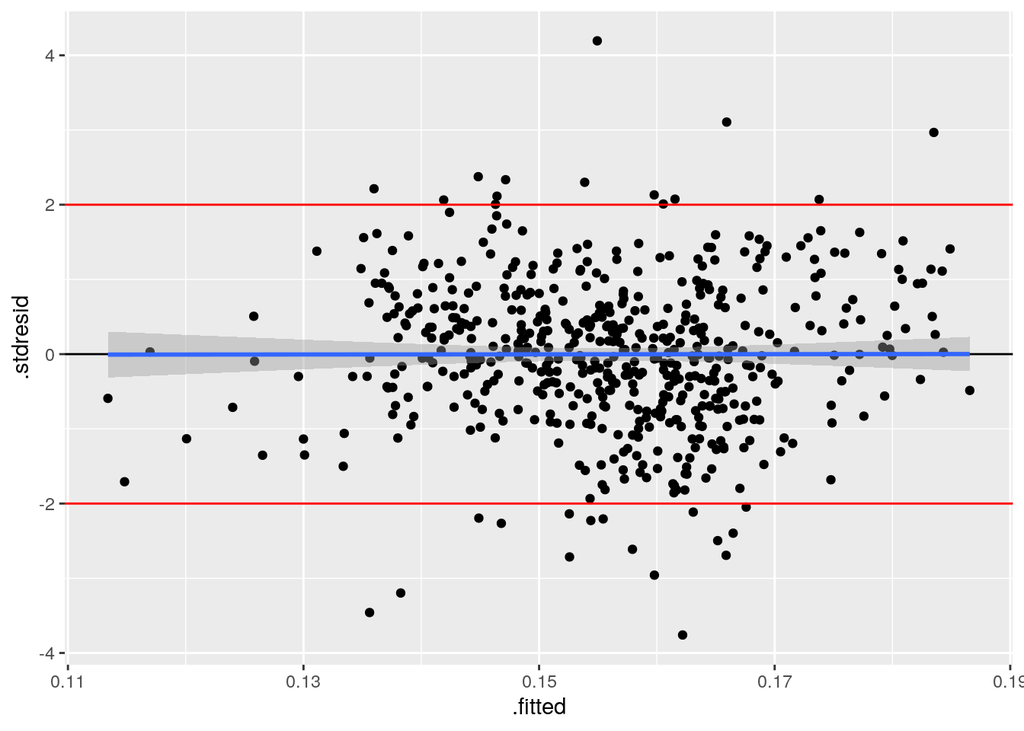

```r
mod_diag <- data.frame(fortify(mod_68), model_data[, c(56, 31, 34, 49, 51, 59, 64, 66, 69)])
gg_resid <- ggplot(data = mod_diag, aes(x = .fitted, y = .stdresid)) +
  geom_point() +
  geom_hline(yintercept = 0) +
  geom_smooth(method = "lm") +
  geom_hline(yintercept = 2, color = "red") +
  geom_hline(yintercept = -2, color = "red")
gg_resid
```

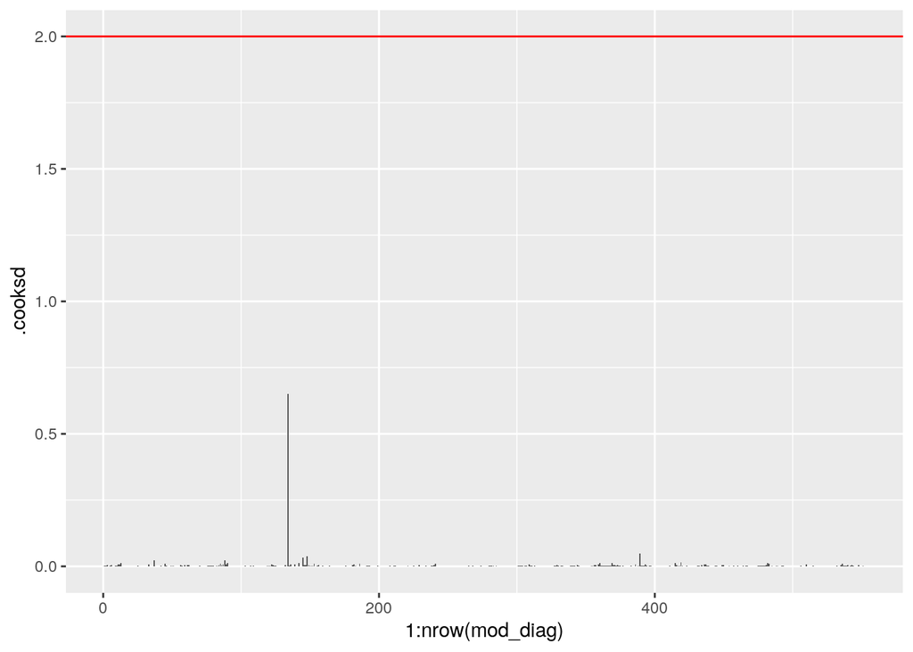

```r
ggplot(mod_diag, aes(x = 1:nrow(mod_diag), y = .cooksd)) +
  geom_bar(stat = "identity") +
  geom_hline(yintercept = 2, color = "red")
```

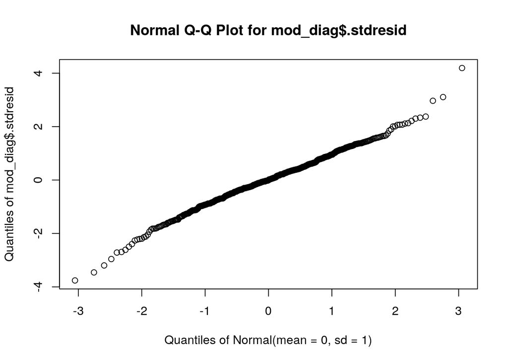

```r
qqPlot(mod_diag$.stdresid)
```

```r
dwt(mod_diag$.fitted)
```

```
## [1] 0.001927575
```

Несмотря на то, что мы получили легитимную модель для предсказания уровня продукции белка ERBB4_N, такой метод является нежелательным из-за ограничений во времени, из-за проблем проверки неучтенных зависимостей от предикторов, удаленных на этапе проверки на мультиколлинеарность и что самое главное, в этой модели мы предсказываем уровень ERBB4_N относительно уровней других белков, полученных в восьми разных случаях.

## PCA

Последним заданием было провести PCA на предложенном датасете.

```r
pca <- rda(model_data, scale = TRUE)
head(summary(pca))
```

```
##
## Call:
## rda(X = model_data, scale = TRUE)
##
## Partitioning of correlations:
##               Inertia Proportion
## Total              77          1
## Unconstrained      77          1
##
## Eigenvalues, and their contribution to the correlations
##
## Importance of components:
##                           PC1     PC2     PC3     PC4     PC5     PC6
## Eigenvalue            23.0488 13.3587 7.58646 7.16154 3.28242 3.04234
## Proportion Explained   0.2993  0.1735 0.09853 0.09301 0.04263 0.03951
## Cumulative Proportion  0.2993  0.4728 0.57135 0.66436 0.70699 0.74650
##                           PC7     PC8     PC9    PC10    PC11    PC12
## Eigenvalue            2.36733 2.25528 1.83075 1.27872 1.11166 0.98313
## Proportion Explained  0.03074 0.02929 0.02378 0.01661 0.01444 0.01277
## Cumulative Proportion 0.77724 0.80653 0.83031 0.84691 0.86135 0.87412
##                          PC13     PC14     PC15     PC16     PC17     PC18
## Eigenvalue            0.86294 0.700922 0.611169 0.569217 0.520420 0.484876
## Proportion Explained  0.01121 0.009103 0.007937 0.007392 0.006759 0.006297
## Cumulative Proportion 0.88533 0.894428 0.902366 0.909758 0.916517 0.922814
##                           PC19     PC20     PC21     PC22     PC23
## Eigenvalue            0.418534 0.399046 0.387367 0.339991 0.319123
## Proportion Explained  0.005436 0.005182 0.005031 0.004415 0.004144
## Cumulative Proportion 0.928249 0.933432 0.938462 0.942878 0.947022
##                           PC24     PC25     PC26     PC27    PC28     PC29
## Eigenvalue            0.292254 0.259013 0.241727 0.216222 0.20709 0.182731
## Proportion Explained  0.003796 0.003364 0.003139 0.002808 0.00269 0.002373
## Cumulative Proportion 0.950818 0.954182 0.957321 0.960129 0.96282 0.965192
##                           PC30     PC31     PC32     PC33     PC34
## Eigenvalue            0.166772 0.150604 0.136755 0.133922 0.124826
## Proportion Explained  0.002166 0.001956 0.001776 0.001739 0.001621
## Cumulative Proportion 0.967358 0.969314 0.971090 0.972829 0.974450
##                           PC35     PC36     PC37    PC38     PC39     PC40
## Eigenvalue            0.123532 0.112486 0.105178 0.09622 0.091371 0.091173
## Proportion Explained  0.001604 0.001461 0.001366 0.00125 0.001187 0.001184
## Cumulative Proportion 0.976054 0.977515 0.978881 0.98013 0.981317 0.982501
```

[output cut: 46 more lines]

```
## NR2A_N   -1.3164 -0.3703  0.56759  0.2723 -0.02731  0.04109
## pAKT_N   -1.0192  0.8742 -0.23253 -0.6059 -0.35846  0.03465
## ....
##
##
## Site scores (weighted sums of species scores)
##
##          PC1     PC2       PC3    PC4    PC5    PC6
## sit1 -0.7976 -0.5826  0.143685 0.5628 0.8218 0.3433
## sit2 -0.7412 -0.4971  0.058363 0.6059 1.0285 0.4438
## sit3 -0.8751 -0.5060  0.110153 0.4895 1.0174 0.3225
## sit4 -0.3027 -0.5902  0.194312 0.3097 0.1477 0.5615
## sit5 -0.3677 -0.4779  0.003043 0.3519 0.5272 0.5926
## sit6 -0.3706 -0.4671 -0.014077 0.4099 0.4814 0.4927
## ....
```

Мы видим, что количество главных компонент совпадает с количеством исследуемых белков, однако процент дисперсии данных, который объясняет каждая компонента, различается, что можно видеть в строке Proportion explained:

```r
eigenvals(pca)
```

```
##       PC1       PC2       PC3       PC4       PC5       PC6       PC7
## 23.048769 13.358730  7.586460  7.161540  3.282417  3.042340  2.367325
##       PC8       PC9      PC10      PC11      PC12      PC13      PC14
##  2.255275  1.830755  1.278718  1.111660  0.983128  0.862944  0.700922
##      PC15      PC16      PC17      PC18      PC19      PC20      PC21
##  0.611169  0.569217  0.520420  0.484876  0.418534  0.399046  0.387367
##      PC22      PC23      PC24      PC25      PC26      PC27      PC28
##  0.339991  0.319123  0.292254  0.259013  0.241727  0.216222  0.207092
##      PC29      PC30      PC31      PC32      PC33      PC34      PC35
##  0.182731  0.166772  0.150604  0.136755  0.133922  0.124826  0.123532
##      PC36      PC37      PC38      PC39      PC40      PC41      PC42
##  0.112486  0.105178  0.096223  0.091371  0.091173  0.082556  0.079101
##      PC43      PC44      PC45      PC46      PC47      PC48      PC49
##  0.073403  0.072582  0.068041  0.064501  0.063126  0.057797  0.054778
##      PC50      PC51      PC52      PC53      PC54      PC55      PC56
##  0.052243  0.050093  0.046612  0.045605  0.044344  0.041069  0.040150
##      PC57      PC58      PC59      PC60      PC61      PC62      PC63
##  0.036550  0.033006  0.032225  0.031406  0.030634  0.028139  0.026891
##      PC64      PC65      PC66      PC67      PC68      PC69      PC70
##  0.024267  0.021985  0.019966  0.018751  0.018173  0.016725  0.013910
##      PC71      PC72      PC73      PC74      PC75      PC76
##  0.012476  0.011562  0.011114  0.008883  0.008621  0.006107
```

Чем больше главных компонент мы берем в анализ, тем больше процент объясняемой дисперсии стремится к 100%, однако, если мы возьмем всего 3 главные компоненты, мы уже объясним 57% от общей дисперсии. Процент объясняемой дисперсии можно отобразить на графике:

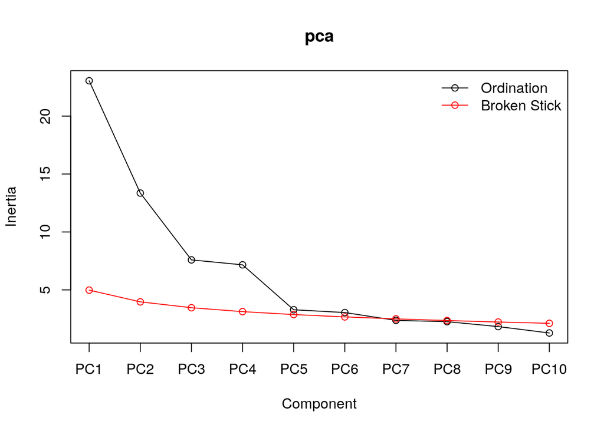

```r
screeplot(pca, type = "lines", bstick = TRUE)
```

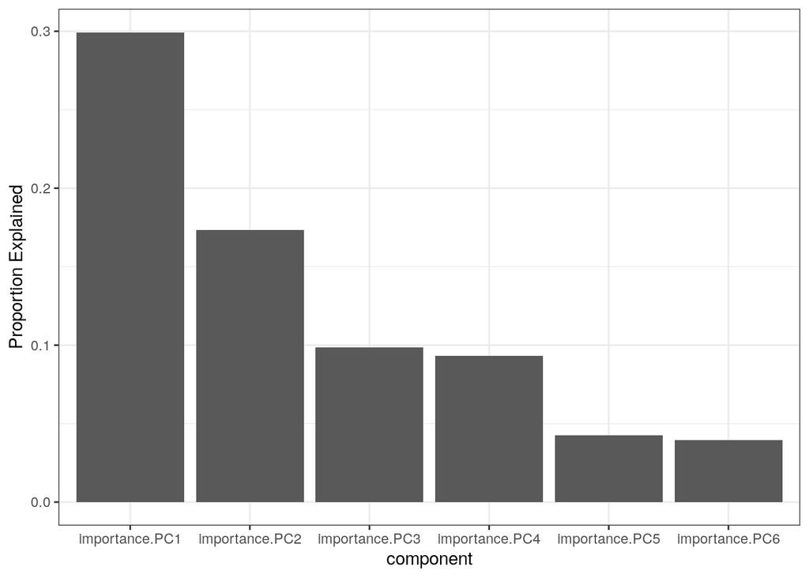

```r
pca_summary <- summary(pca)
pca_result <- as.data.frame(pca_summary$cont)
plot_data <- as.data.frame(t(pca_result[c("Proportion Explained"),]))
plot_data$component <- rownames(plot_data)
ggplot(plot_data[1:6, ], aes(component, `Proportion Explained`)) + geom_bar(stat = "identity") + theme_bw()
```

График факторных нагрузок (ниже) отображает направление осей исходных признаков (собственные векторы) относительно осей главных компонент: из этого графика мы можем оценить как соотносятся главные компоненты и исходные признаки (со- , антинаправленно, не зависят друг от друга), а также корреляцию исходных признаков.

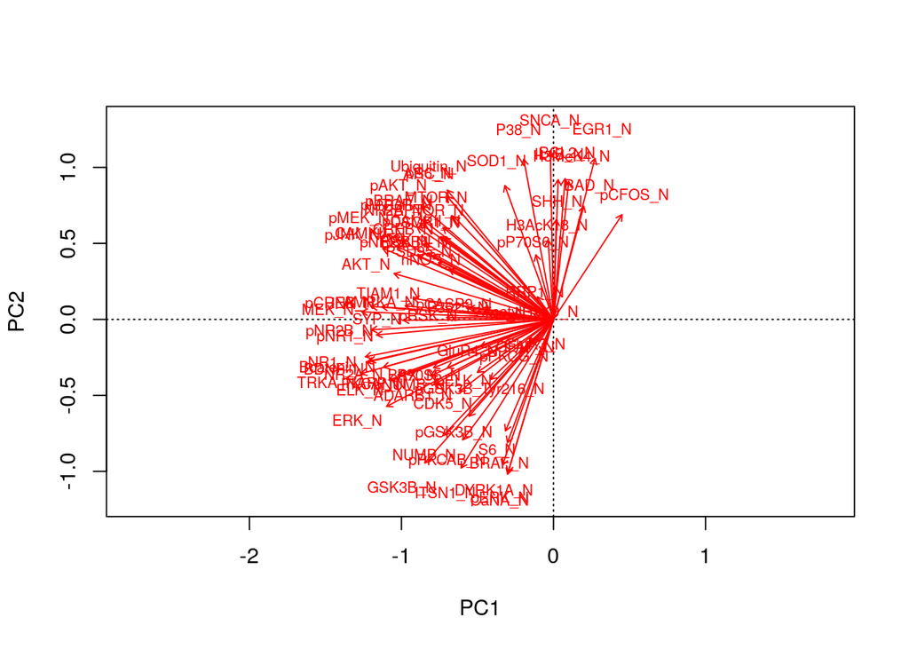

```r
biplot(pca, scaling = "species", display = "species")
```

Наверное, самая интересная часть РСА - это построение графиков ординации. На графике ниже собственные числа показывают дисперсию вдоль собственных векторов. Расстояния между точками (объектами - сигналами об уровне белков в лунках планшета) апроксимируют евклидовы расстояния и отражают сходство между изучаемыми объектами и классами, к которым они относятся.

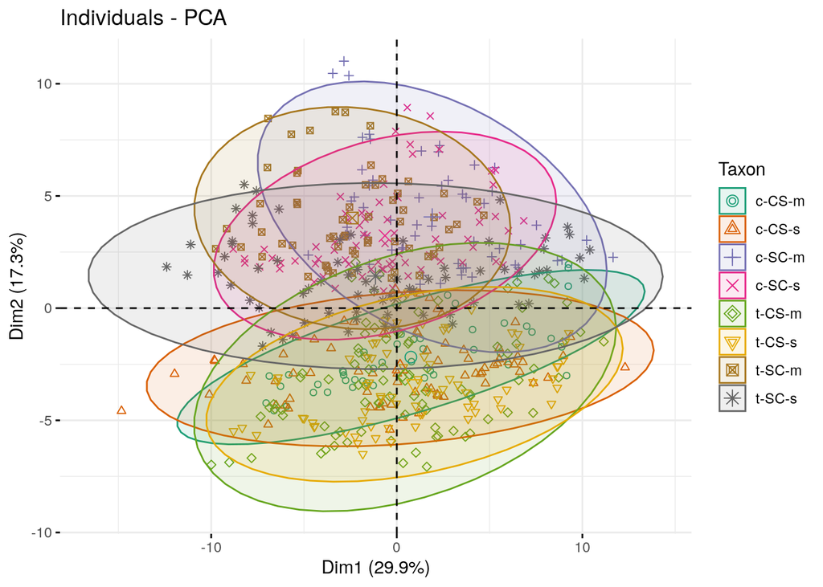

```r
pca_base <- prcomp(model_data, scale = TRUE)
fviz_pca_ind(pca_base,
             geom.ind = "point", # show points only (nbut not "text")
             col.ind = df$class, # color by groups
             palette = "Dark2",
             addEllipses = TRUE, # Concentration ellipses
             legend.title = "Taxon"
             )
```

```r
ord<-metaMDS(comm = model_data, distance = "bray",autotransform = F)
```

```
## *** No convergence -- monoMDS stopping criteria:
##     18: stress ratio > sratmax
##      2: scale factor of the gradient < sfgrmin
```

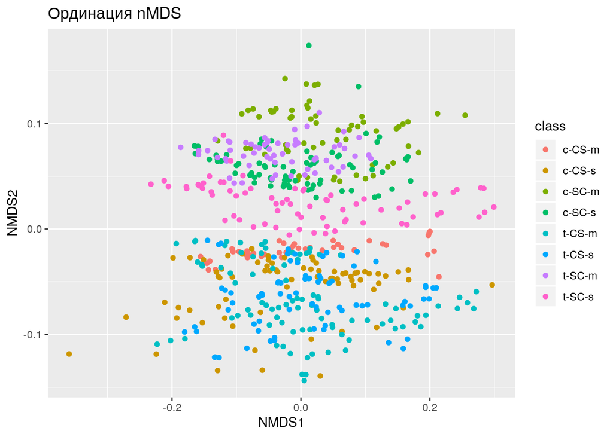

```r
ord_pt <- data.frame(df[, 82], scores(ord, display = "sites"))
ggplot(ord_pt, aes(NMDS1, NMDS2, color = class))+geom_point()+ggtitle(label = "Ординация nMDS")
```

Графики можно строить также относительно трёх главных компонент. Для этого мы воспользуемся пакетом pca3d (если не открывается через этот файл, надо выполнить код ниже).

```r
gr <- factor(df$class)
pca3d(pca_base, group = gr)
```

```
## [1] 0.2966606 0.2201412 0.1879875
## Creating new device
```

```r
#Альтернативно можно попробовать вызвать скриншот в Rmd следующими командами
#snapshotPCA3d(file="pca.png")
```